# Week 2 Missing Data and Smoothing Models

20 pts - Exploratory Data Analysis

```python
import pandas as pd
#Loading the dataset
data= data = pd.read_csv("hw2_data.csv")
# first few rows of the dataset
data_info = data.info()
data_head = data.head()

data_info, data_head
```

```
<class 'pandas.core.frame.DataFrame'>
RangeIndex: 4972 entries, 0 to 4971
Data columns (total 4 columns):
 #   Column  Non-Null Count  Dtype
---  ------  --------------  -----
 0   Date    4972 non-null   object
 1   IWM     4075 non-null   float64
 2   QQQ     4075 non-null   float64
 3   SPY     4075 non-null   float64
dtypes: float64(3), object(1)
memory usage: 155.5+ KB
```

```
(None,
          Date        IWM        QQQ         SPY
 0  2000-05-26  34.800865  67.670738   93.363678
 1  2000-05-30        NaN        NaN         NaN
 2  2000-05-31        NaN        NaN         NaN
 3  2000-06-01  37.036850  76.048004   98.310966
 4  2000-06-02  38.963646  81.487755  100.023491)
```

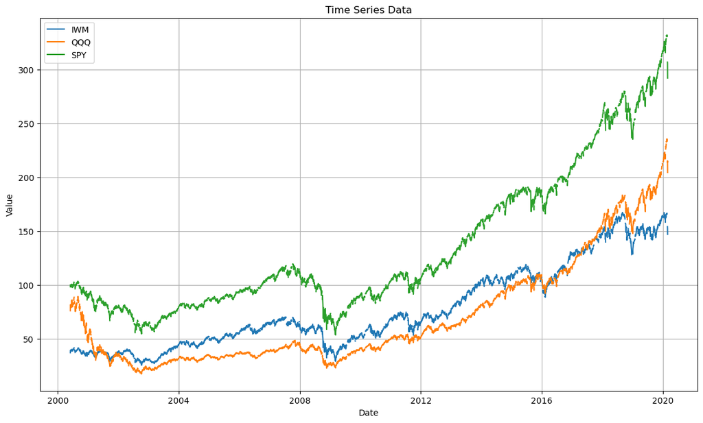

```python
import matplotlib.pyplot as plt

# Converting Date column to datetime
data['Date'] = pd.to_datetime(data['Date'])

# Plotting the time series data
plt.figure(figsize=(14, 8))

plt.plot(data['Date'], data['IWM'], label='IWM')
plt.plot(data['Date'], data['QQQ'], label='QQQ')
plt.plot(data['Date'], data['SPY'], label='SPY')

plt.xlabel('Date')
plt.ylabel('Value')
plt.title('Time Series Data')
plt.legend()
plt.grid(True)
plt.show()
```

# Yes, there appears to be missing data.

```python
# Calculating the number of NA values
na_counts = data[['IWM', 'QQQ', 'SPY']].isna().sum()

# Calculating the percentage of missing data
na_percentage = (na_counts / len(data)) * 100
na_counts, na_percentage
```

```
(IWM    897
 QQQ    897
 SPY    897
 dtype: int64,
 IWM    18.04103
 QQQ    18.04103
 SPY    18.04103
 dtype: float64)
```

Financial rish modeling: In financial risk modeling,missing data can significantly impact the reliability of risk assessments and the robustness of the models. Proceeding with 18.04% missing data could lead to inaccurate risk estimations, may result in substantial financial losses or regulatory issues.

Proceeding with 18.04% Missing Data: Preliminary Market Analysis: Preliminary market analysis which invloves ETA to identify patterns, trends , and anomalies. Proper imputation technique if applied proceeding with 18.04% missing data could still yield valuable insights without critically impacting the initial exploratory findings.

20 pts - Missing Data

```python
import warnings
warnings.filterwarnings('ignore')

# Forward-fill
forward_fill = data.fillna(method='ffill')

# Backward-fill
backward_fill = data.fillna(method='bfill')

# Moving average fill
moving_average_fill = data.copy()
moving_average_fill[['IWM', 'QQQ', 'SPY']] = moving_average_fill[['IWM', 'QQQ', 'SPY']].fillna(
    moving_average_fill[['IWM', 'QQQ', 'SPY']].rolling(window=3, min_periods=1).mean()
)

# Interpolation
interpolated_fill = data.interpolate()

# Displaying  the first few rows
forward_fill.head(), backward_fill.head(), moving_average_fill.head(), interpolated_fill.head()
```

```
(        Date        IWM        QQQ         SPY
 0 2000-05-26  34.800865  67.670738   93.363678
 1 2000-05-30  34.800865  67.670738   93.363678
 2 2000-05-31  34.800865  67.670738   93.363678
 3 2000-06-01  37.036850  76.048004   98.310966
 4 2000-06-02  38.963646  81.487755  100.023491,
         Date        IWM        QQQ         SPY
 0 2000-05-26  34.800865  67.670738   93.363678
 1 2000-05-30  37.036850  76.048004   98.310966
 2 2000-05-31  37.036850  76.048004   98.310966
 3 2000-06-01  37.036850  76.048004   98.310966
 4 2000-06-02  38.963646  81.487755  100.023491,
         Date        IWM        QQQ         SPY
 0 2000-05-26  34.800865  67.670738   93.363678
 1 2000-05-30  34.800865  67.670738   93.363678
 2 2000-05-31  34.800865  67.670738   93.363678
 3 2000-06-01  37.036850  76.048004   98.310966
 4 2000-06-02  38.963646  81.487755  100.023491,
         Date        IWM        QQQ         SPY
 0 2000-05-26  34.800865  67.670738   93.363678
 1 2000-05-30  35.546193  70.463160   95.012774
 2 2000-05-31  36.291522  73.255582   96.661870
 3 2000-06-01  37.036850  76.048004   98.310966
 4 2000-06-02  38.963646  81.487755  100.023491)
```

Smoothing methods

```python
pip install sktime
```

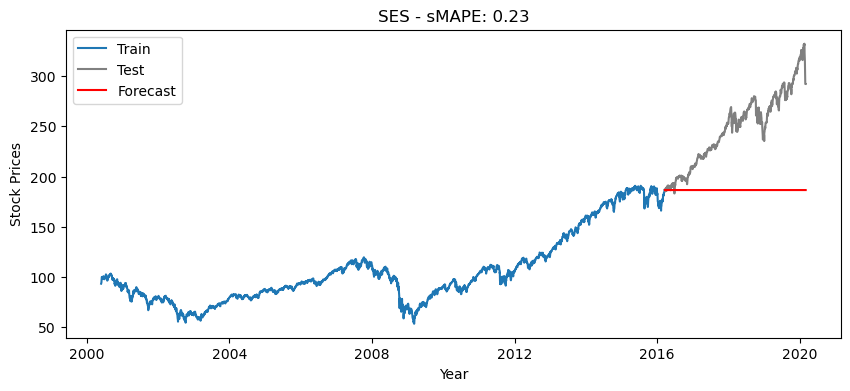

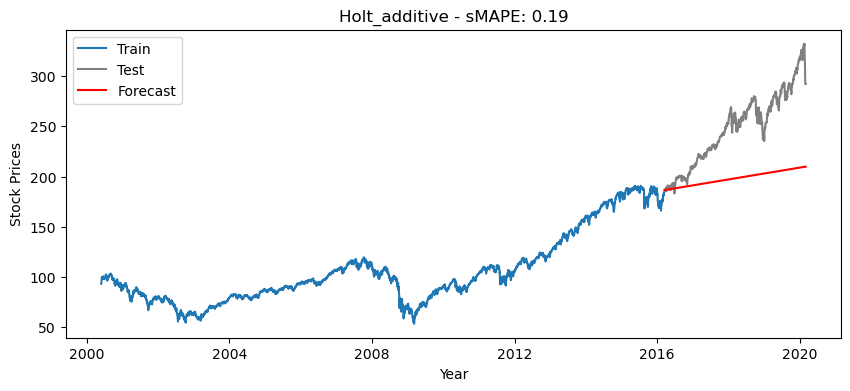

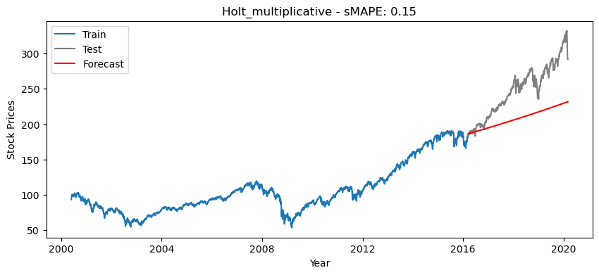

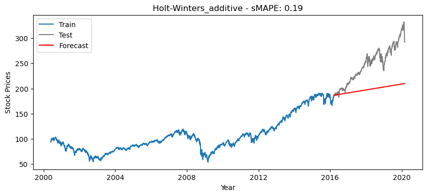

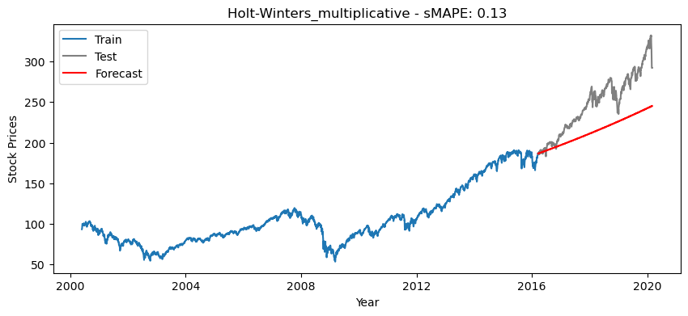

```
SES Forecasting Error (sMAPE): 0.23
Holt_additive Forecasting Error (sMAPE): 0.19
Holt_multiplicative Forecasting Error (sMAPE): 0.15
Holt-Winters_additive Forecasting Error (sMAPE): 0.19
Holt-Winters_multiplicative Forecasting Error (sMAPE): 0.13
```

```python
import pandas as pd
from sktime.forecasting.model_selection import temporal_train_test_split
from sktime.forecasting.base import ForecastingHorizon
from sktime.forecasting.exp_smoothing import ExponentialSmoothing
from sktime.performance_metrics.forecasting import mean_absolute_percentage_error
import matplotlib.pyplot as plt

# Loading data
data = pd.read_csv('hw2_data.csv')
data['Date'] = pd.to_datetime(data['Date'])
data.set_index('Date', inplace=True)

# Missing values handle
data = data.resample('b').interpolate('linear').ffill().bfill()

# Selecting SPY series and data split
spy_series = data['SPY']
y_train, y_test = temporal_train_test_split(spy_series, test_size=0.2)
fh = ForecastingHorizon(y_test.index, is_relative=False)

def apply_and_plot_smoothing_methods(y_train, y_test, fh):
    results = {}
    methods = {
        "SES": ExponentialSmoothing(sp=1, seasonal=None),
        "Holt_additive": ExponentialSmoothing(trend='add', sp=12, seasonal=None),
        "Holt_multiplicative": ExponentialSmoothing(trend='mul', sp=12, seasonal=None),
        "Holt-Winters_additive": ExponentialSmoothing(trend='add', sp=12, seasonal='additive'),
        "Holt-Winters_multiplicative": ExponentialSmoothing(trend='mul', sp=12, seasonal='multiplicative')
    }

    for name, model in methods.items():
        model.fit(y_train)
        y_pred = model.predict(fh)
        sMAPE = mean_absolute_percentage_error(y_test, y_pred)
        results[name] = (y_pred, sMAPE)

        plt.figure(figsize=(10, 4))
        plt.title(f"{name} - sMAPE: {sMAPE:.2f}")
        plt.plot(y_train.index, y_train, label='Train')
        plt.plot(y_test.index, y_test, label='Test', color='gray')
        plt.plot(y_pred.index, y_pred, label='Forecast', color='red')
        plt.xlabel('Year')
        plt.ylabel('Stock Prices')
        plt.legend()
        plt.show()

    return results

forecast_results = apply_and_plot_smoothing_methods(y_train, y_test, fh)
for method, (predictions, error) in forecast_results.items():
    print(f"{method} Forecasting Error (sMAPE): {error:.2f}")
```

Holt-Winters multiplicative model works best among those tested,has the lowest sMAPE at 0.13, indicates the most accurate forecasts among the models tested.These models might not be the best for to model stock price data due to the efficient market hypothesis, which suggests that stock prices reflect all available information and are thus inherently unpredictable. However, they could be useful for smooting out short-term fluctuations and indentifying broader terms. These models are better suited for forecasting data with consistent patterns and trends without too many external disruptions.

THE END